# PPOL 563 Spring 2023 - Problem Set 1

Alex Lundry

2023-01-31

## Problem Set 1 - PPOL 563 Spring 2023

The first set of questions require you to work with the **Global Power Plant Database** contained in this repository. You can also find associated documentation for the dataset, including a data dictionary, a README file and release notes. The data and all associated materials can be found [here](https://datasets.wri.org/dataset/globalpowerplantdatabase).

```r
knitr::opts_chunk$set(echo = FALSE, message = FALSE, warning = FALSE)

library(tidyverse)
library(countrycode)
library(ggrepel)
library(scales)

# Data originally downloaded from:
# https://datasets.wri.org/dataset/globalpowerplantdatabase
d1 <- read_csv("global_power_plant_database_v_1_3/global_power_plant_database.csv")

# Pre-add continent for problem set
d1$continent <- countrycode(sourcevar = d1[, "country"] %>% pull(),
                            # pull out the country column from orig data as a vector
                            origin = 'iso3c', # naming convention of the orig data
                            destination = "continent") # name of new var to create

# Add continent for missing data
# Add a renewable energy flag
d1 <- d1 %>%
   mutate(continent = case_when(country_long == "Antarctica" ~ "Antarctica",
                                country_long == "Kosovo" ~ "Europe",
                                TRUE ~ continent),
          renewable = ifelse(primary_fuel %in% c("Solar", "Hydro", "Wind",
                                                 "Biomass", "Geothermal", "Wave and Tidal"),
                             "Renewable Energy", "Non-Renewable Energy"))
```

**Question 1**: Reproduce the 100% stacked barchart below. This is a visualization of a count of facilities by `continent` grouped by the `renewable` variable, and then computed as proportions. Take note of the text labels, which are:

- rounded to a whole number
- text is white
- % suffix
- in the middle of their respective colored bar

Please insert your own meaningful title and subtitle.

**BONUS: (not required)** - Sort the continents in descending order based on the the percent renewable energy, without manually declaring their order.  
___

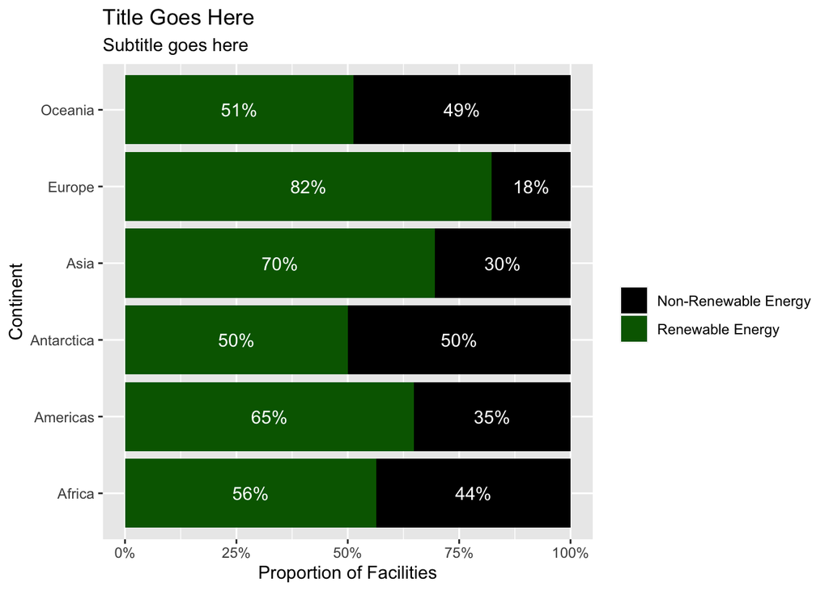

For the second question of the problem set, you will be required to make your own visualizations without any reference viz to guide you. You may choose to use either of the following data sets, which are included in the Problem Set repository:

- `chicago_schools.csv`, a file of progress report cards for Chicago schools from 2011-2012. You can find the documentation for this dataset [here](https://data.cityofchicago.org/Education/Chicago-Public-Schools-Progress-Report-Cards-2011-/9xs2-f89t). The provided data is adjusted so that the variable names are easier to work with in R.
- `gun_background_checks`, a file of Firearm Background Check data collected by the FBI. You can find details on the data [here](https://github.com/BuzzFeedNews/nics-firearm-background-checks)

**Question 2**: Create a scatterplot using two numeric variables from the data. Use a categorical variable to highlight *one* category from the data. (For example, the `safety_icon` variable in the `chicago_schools.csv` data has six categories, but your visualization should only highlight one category with a color).

> Your plot should have a legend (if necessary), descriptive title and subtitle, should *not* use default `ggplot2` colors or the default `ggplot2` theme, and all plot elements should be human readable (no overlapping text, no acronyms unless they are defined, no underscores). Axis scales should make sense and be rounded to 2 digits or less (if applicable).

**BONUS: (not required)** - add a faint dotted line that represents the average for X axis variable. Do the same for the Y axis variable.